# Practical Machine Learning - Course Project

## III. Modeling

### Method 1: Random Forests Approach

First, Random Forests modeling is attempted. Notice the use of parallel computing and a change from default resampling method to imrpove the computing speed.

```r
set.seed(12345)

#Configure parallele computing
library(parallel)
library(doParallel)
cluster <- makeCluster(detectCores() - 4) #leave 4 cores for others
registerDoParallel(cluster)

##changing the resampling method from the default of bootstrapping to k-fold (k=5) cross-validation
fitControl <- trainControl(method = "cv", number = 5, allowParallel = TRUE, verboseIter=FALSE)
Modelfit1 <- train(classe ~ . ,method="rf", data=training.train, trControl= fitControl )
save(Modelfit1, file = "Modelfit1.RData")
##De-register parallel processing cluster
stopCluster(cluster)
```

```r
Modelfit1
```

```
## Random Forest
##
## 13737 samples
##    57 predictors
##     5 classes: 'A', 'B', 'C', 'D', 'E'
##
## No pre-processing
## Resampling: Cross-Validated (5 fold)
## Summary of sample sizes: 10989, 10989, 10989, 10990, 10991
## Resampling results across tuning parameters:
##
##   mtry  Accuracy   Kappa
##    2    0.9884982  0.9854483
##   40    0.9984712  0.9980662
##   79    0.9979616  0.9974217
##
## Accuracy was used to select the optimal model using  the largest value.
## The final value used for the model was mtry = 40.
```

```r
confusionMatrix.train(Modelfit1)  ##--> accuracy at 0.9985. Or, equivalently, the error rate was 0.0015
```

```
## Cross-Validated (5 fold) Confusion Matrix
##
## (entries are percentual average cell counts across resamples)
##
##           Reference
## Prediction    A    B    C    D    E
##          A 28.4  0.0  0.0  0.0  0.0
##          B  0.0 19.3  0.0  0.0  0.0
##          C  0.0  0.0 17.4  0.0  0.0
##          D  0.0  0.0  0.0 16.4  0.0
##          E  0.0  0.0  0.0  0.0 18.3
##
##  Accuracy (average) : 0.9985
```

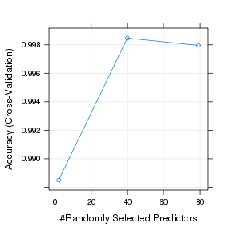

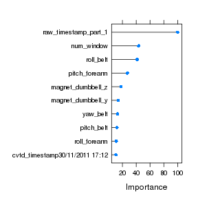

```r
par(mfrow=c(1,2))
plot(Modelfit1) ## --> sample accuracy peaks at 0.9985, with 40 predictors
plot(varImp(Modelfit1), top = 10)
```

Use this model to make prediction on training.test to validate the error rate.

```r
# prediction on training.test dataset
pred1test <- predict(Modelfit1, newdata=training.test)
confusionMatrix1 <- confusionMatrix(pred1test, training.test$classe)
confusionMatrix1    ##--> accuracy at 0.9988.  Or, equivalently, the error rate was 0.0012. Not very different from that in the traning.train.
```

```
## Confusion Matrix and Statistics
##
##           Reference
## Prediction    A    B    C    D    E
##          A 1674    0    0    0    0
##          B    0 1139    0    0    0
##          C    0    0 1019    0    0
##          D    0    0    7  964    0
##          E    0    0    0    0 1082
##
## Overall Statistics
##
##                Accuracy : 0.9988
##                  95% CI : (0.9976, 0.9995)
##     No Information Rate : 0.2845
##     P-Value [Acc > NIR] : < 2.2e-16
##
##                   Kappa : 0.9985
##  Mcnemar's Test P-Value : NA
##
## Statistics by Class:
##
##                      Class: A Class: B Class: C Class: D Class: E
## Sensitivity            1.0000   1.0000   0.9932   1.0000   1.0000
## Specificity            1.0000   1.0000   1.0000   0.9986   1.0000
## Pos Pred Value         1.0000   1.0000   1.0000   0.9928   1.0000
## Neg Pred Value         1.0000   1.0000   0.9986   1.0000   1.0000
## Prevalence             0.2845   0.1935   0.1743   0.1638   0.1839
## Detection Rate         0.2845   0.1935   0.1732   0.1638   0.1839
## Detection Prevalence   0.2845   0.1935   0.1732   0.1650   0.1839
## Balanced Accuracy      1.0000   1.0000   0.9966   0.9993   1.0000
```

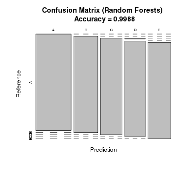

```r
###plot confusion matrix
plot(confusionMatrix1$table,  col = NULL, cex=0.6, main = paste("Confusion Matrix (Random Forests) \n Accuracy =", round(confusionMatrix1$overall['Accuracy'], 4)))
```

The out-of-sample accuracy was an impressive 0.9988, or eqivalently, the error rate was 0.0012 !

### Method 2 : Generalized Boosted Model

Again, paralel computing was used for efficient processing.

```r
set.seed(12345)

#Configure parallele computing
library(parallel)
library(doParallel)
cluster <- makeCluster(detectCores() - 4) #leave 4 cores for others
registerDoParallel(cluster)

fitControl <- trainControl(method = "repeatedcv", number = 5, repeats = 1)
Modelfit2 <- train(classe ~ ., data=training.train, method = "gbm", trControl = fitControl, verbose = FALSE)
save(Modelfit2, file = "Modelfit2.RData")
##De-register parallel processing cluster
stopCluster(cluster)
```

```r
confusionMatrix.train(Modelfit2)    ####--> accuracy at 0.9963.  Or, equivalently, the error rate wais 0.0037
```

```
## Cross-Validated (5 fold, repeated 1 times) Confusion Matrix
##
## (entries are percentual average cell counts across resamples)
##
##           Reference
## Prediction    A    B    C    D    E
##          A 28.4  0.1  0.0  0.0  0.0
##          B  0.0 19.3  0.0  0.0  0.0
##          C  0.0  0.0 17.3  0.0  0.0
##          D  0.0  0.0  0.1 16.3  0.1
##          E  0.0  0.0  0.0  0.1 18.3
##
##  Accuracy (average) : 0.9963
```

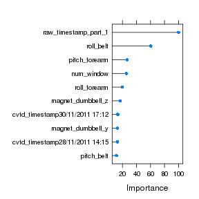

```r
plot(varImp(Modelfit2), top = 10)
```

Use this model to make prediction on training.test to validate the error rate.

```r
# prediction on training.test dataset
pred2test <- predict(Modelfit2, newdata=training.test)
confusionMatrix2 <- confusionMatrix(pred2test, training.test$classe)
confusionMatrix2    ##--> accuracy at 0.9964, or, equivalently, the error rate at 0.0036
```

```
## Confusion Matrix and Statistics
##
##           Reference
## Prediction    A    B    C    D    E
##          A 1673    4    0    0    0
##          B    1 1134    1    0    0
##          C    0    0 1016    0    0
##          D    0    1    9  962    3
##          E    0    0    0    2 1079
##
## Overall Statistics
##
##                Accuracy : 0.9964
##                  95% CI : (0.9946, 0.9978)
##     No Information Rate : 0.2845
##     P-Value [Acc > NIR] : < 2.2e-16
##
##                   Kappa : 0.9955
##  Mcnemar's Test P-Value : NA
##
## Statistics by Class:
##
##                      Class: A Class: B Class: C Class: D Class: E
## Sensitivity            0.9994   0.9956   0.9903   0.9979   0.9972
## Specificity            0.9991   0.9996   1.0000   0.9974   0.9996
## Pos Pred Value         0.9976   0.9982   1.0000   0.9867   0.9981
## Neg Pred Value         0.9998   0.9989   0.9979   0.9996   0.9994
## Prevalence             0.2845   0.1935   0.1743   0.1638   0.1839
## Detection Rate         0.2843   0.1927   0.1726   0.1635   0.1833
## Detection Prevalence   0.2850   0.1930   0.1726   0.1657   0.1837
## Balanced Accuracy      0.9992   0.9976   0.9951   0.9976   0.9984
```

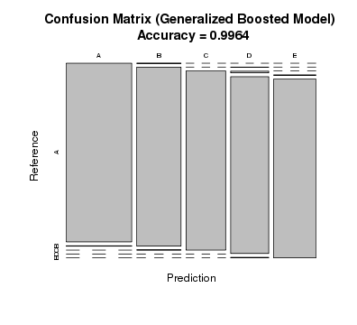

```r
###plot confusion matrix
plot(confusionMatrix2$table,  col = NULL, cex = 0.6, main = paste("Confusion Matrix (Generalized Boosted Model) \n Accuracy =", round(confusionMatrix2$overall['Accuracy'], 4)))
```

The out-of-sample accuracy was also an impressive 0.9964, or, equivalently, the error rate was 0.0036!

Both of Random Forests and Generalized Boosted Model had close to perfect out-of-sample accuracy/error rate.

# Results

Two methods were a virtual tie. But since Random Forests model had a slight nominal adavntage, I chose Random Forests to make the final prediction on the provided testing set (**pml-testing.csv**, N=20).

```
##  [1] B A B A A E D B A A B C B A E E A B B B
## Levels: A B C D E
```

This set of prediction achieved a 100% accuracy ! (Similarly and not surprisingly, the GBM model made the same predictions for the final tes set of 20)